# 231b Section 3

Natalia Garbiras-Díaz nataliagarbirasdiaz+231b@berkeley.edu

February 3, 2017

# Today

**1. Standard error for the difference in means**

**2. Hypothesis testing**

- 2a. T-test
- 2b. Randomization inference

**3. Bivariate Regression**

# 1. Standard error for the difference in means

- You have shown in problem set 1 that the difference in means is an unbiased estimator of the true ATE. However, by chance, in some realizations of our sample that estimate might be off the true ATE.
- The SE tells us the likely size of the amount off.

We are going to estimate the SE for the difference in means using the data from Chattopadhyay and Duflo (2004) referenced in Gerber and Green (2012).

```r
# the data
gg_data <- as.data.frame(cbind(c(10,15,20,20,10,15,15),
                               c(15,15,30,15,20,15,30)))
names(gg_data) <- c("Y_i0", "Y_i1")
```

```r
# generating empty dataframe to put the results
ate <- as.data.frame(matrix(NA, 10000, 2))
names(ate) <- c("estimated_ate", "estimated_se_ate")

# sampling
for (i in 1:10000){

  # generating treatment vector for this replicate
  gg_data$treat <- 0
  gg_data$treat[sample(1:7, 2, replace=F)]  <- 1

  treat_mean <- mean(gg_data$Y_i1[gg_data$treat==1])
  treat_var <- var(gg_data$Y_i1[gg_data$treat==1])

  control_mean <- mean(gg_data$Y_i0[gg_data$treat==0])
  control_var <- var(gg_data$Y_i0[gg_data$treat==0])

  ate[i,1] <- treat_mean - control_mean
  ate[i,2] <- sqrt(treat_var/2 + control_var/5)
}
```

Let’s explore how this matrix looks like:

```r
head(ate)
```

```
##   estimated_ate estimated_se_ate
## 1           0.5         2.783882
## 2           1.0         1.870829
## 3           0.0         1.581139
## 4          10.0         5.244044
## 5           1.5         3.122499
## 6          -1.0         1.870829
```

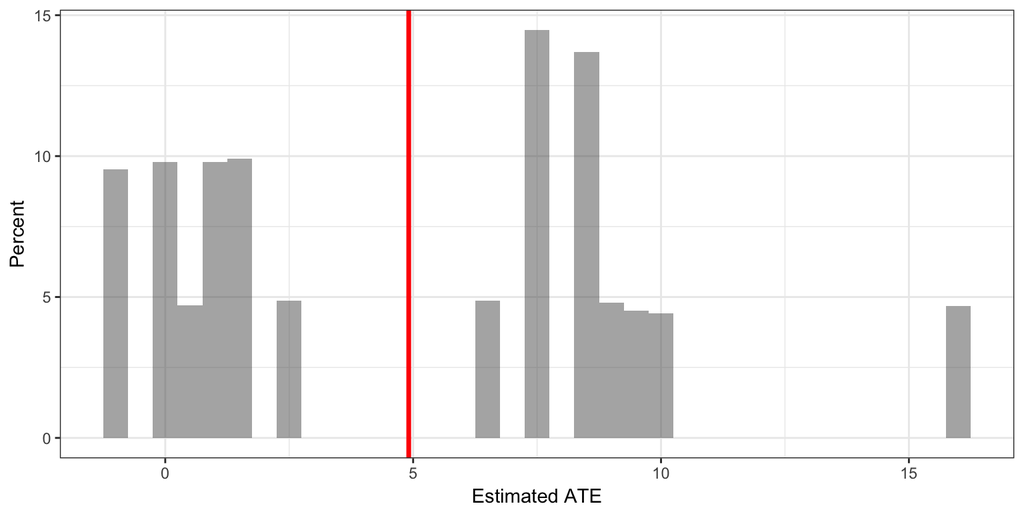

- What should be the title of this figure?
- How could we use this graph to get the SE of the estimated ATE?

```r
# The SE of the estimated ATE is the standard deviation of this sampling distribution:
se_sampling<-sd(ate[,1])
se_sampling
```

```
## [1] 4.586287
```

- Notice, the estimated SE will also have a distribution.

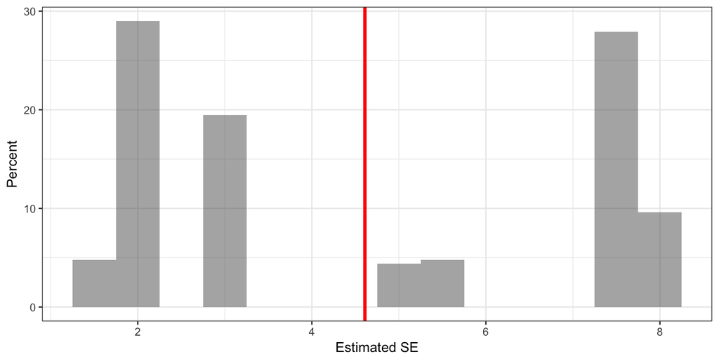

What should the average of the estimated SEs?

```r
# Comparing the true standard error to the conservative formula
se_est<-mean(ate[,2])
print(c(se_sampling, se_est))
```

```
## [1] 4.586287 4.609917
```

# 2. Hypothesis testing

```r
# generating treatment vector for a given experiment
gg_data$treat <- c(1, 0, 0, 0, 0, 0, 1)

# getting observed outcomes
gg_data$observed <- ifelse(gg_data$treat==1, gg_data$Y_i1, gg_data$Y_i0)

# ate
ATE <- mean(gg_data$observed[gg_data$treat==1]) - mean(gg_data$observed[gg_data$treat==0])
ATE
```

```
## [1] 6.5
```

- What is a p-value?

# 2a. T-test

```r
treated <- gg_data$observed[gg_data$treat==1]
treated
```

```
## [1] 15 30
```

```r
var1 <- sum((treated - mean(treated))^2) / (length(treated) - 1)
var1
```

```
## [1] 112.5
```

```r
not_treated <- gg_data$observed[gg_data$treat==0]
not_treated
```

```
## [1] 15 20 20 10 15
```

```r
var0 <- sum((not_treated - mean(not_treated))^2) / (length(not_treated) - 1)
var0
```

```
## [1] 17.5
```

```r
estimated_se <- sqrt(var1/length(treated) + var0/length(not_treated))
estimated_se # Why is this number different from 7.730 (the number in the lecture slides)?
```

```
## [1] 7.729812
```

```r
# rounding error!
```

```r
# converting to standard units: Why is it ATE - 0?
t_stat <- (ATE - 0) / estimated_se
t_stat
```

```
## [1] 0.8409001
```

```r
# To be able to get the right Student t Distribution, we need to calculate
# the degrees of freedom (Satterthwaite)
df <- (var1/length(treated) + var0/length(not_treated))^2 /
           ((var1/length(treated))^2 / (length(treated) - 1) +
           (var0/length(not_treated))^2 / (length(not_treated) - 1))
df
```

```
## [1] 1.127225
```

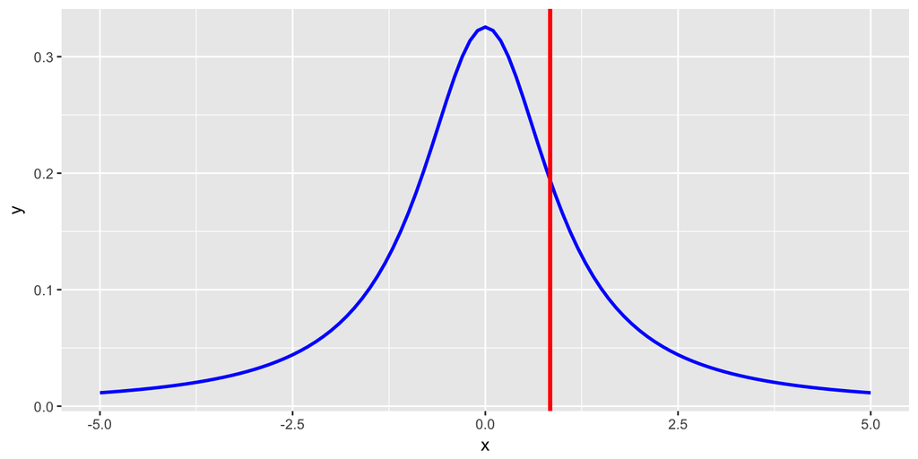

```r
# Overlaying the t_stat to the student t distribution
ggplot(data.frame(x = c(-5, 5)), aes(x)) +
  stat_function(fun=dt, args=list(df=df, ncp=0), col="blue", size=1) +
  geom_vline(xintercept = mean(t_stat), col="red", size=1.25)
```

```r
# One tailed p-value
pt(t_stat, df=df, ncp=0, lower.tail=F)
```

```
## [1] 0.2708243
```

```r
# Two tailed p-value
pt(-t_stat, df=df, ncp=0, lower.tail=T) + pt(t_stat, df=1.12, ncp=0, lower.tail=F)
```

```
## [1] 0.5419946
```

# 2b. Randomization inference

To get all the possible treatment vectors, we will generate 10000 differente ones…

```r
fake_treats <- matrix(NA, 10000, 7)
for (i in 1:10000){
fake_treats[i,] <- sample(gg_data$treat, 7, replace=F)
}
```

… and then only keep the unique ones

```r
fake_treats <- unique(fake_treats)
```

Now we need to calculate the ATE for each of these possible randomizations. For that, we will need a loop

```r
rand_ate <- NA # placeholder vector for results

for (i in 1:nrow(fake_treats)){ # for each of the fake treatment vectors

  mean_treat <- mean(gg_data$observed[fake_treats[i,]==1])

  mean_control <- mean(gg_data$observed[fake_treats[i,]==0])

  # calculating ATE for this randomization
  rand_ate[i] <- mean_treat - mean_control

}
```

Now we can plot the distribution of the randomization ATEs

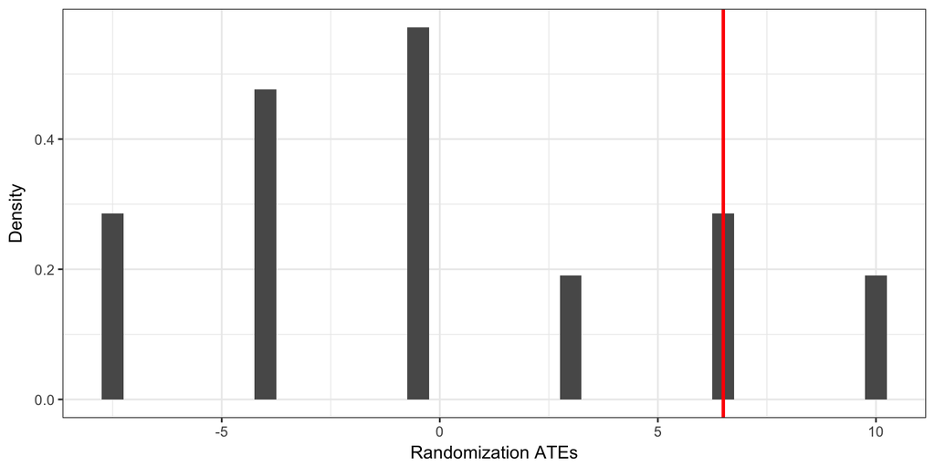

Distribution of randomization ATEs

And we can get the p-value

```r
# One tailed
sum(rand_ate>=ATE)/length(rand_ate)
```

```
## [1] 0.2380952
```

```r
# Two tailed
sum(abs(rand_ate)>=ATE)/length(rand_ate)
```

```
## [1] 0.3809524
```

# 3. Bivariate Regression

We will be using the `family.rda` dataset, which we can download directly from the internet.

```r
load(url("http://www.stat.berkeley.edu/users/nolan/data/stat133/family.rda"))
```

Let’s see what we have here:

```r
dim(family)
```

```
## [1] 14  7
```

```r
family
```

```
##    firstName gender age height weight      bmi overWt
## 1        Tom      m  77     70    175 25.16239   TRUE
## 2        May      f  33     64    125 21.50106  FALSE
## 3        Joe      m  79     73    185 24.45884  FALSE
## 4        Bob      m  47     67    156 24.48414  FALSE
## 5        Sue      f  27     64    105 18.06089  FALSE
## 6        Liz      f  33     68    190 28.94981   TRUE
## 7        Jon      m  67     68    185 28.18797   TRUE
## 8        Sal      f  52     65    124 20.67783  FALSE
## 9        Tim      m  59     68    175 26.66430   TRUE
## 10       Tom      m  27     71    215 30.04911   TRUE
## 11       Ann      f  55     67    166 26.05364   TRUE
## 12       Dan      m  24     66    140 22.64384  FALSE
## 13       Art      m  46     66    150 24.26126  FALSE
## 14       Zoe      f  48     62    125 22.91060  FALSE
```

# We will work on linear regression with 4 coding exercises

- Work in groups for each exercise
- Upload your code to codeshare https://codeshare.io/2pqoZ4. Before your code, please include a group identifier (e.g., “Group A”)

A. Write a function that calculates `r`, the correlation between two variables. Use only the functions `sum()`, `mean()`, `sqrt()` and `length()`.

```r
r <- function(x, y){
  # This function takes two variables as input and returns their correlation.

}
```

One way we could do this:

```r
# Correlation function using sum, mean, and length
r <- function(x, y) {
  # this function takes two variables as input and returns their correlation.

  # lengths
  n_x = length(x)
  n_y = length(y)

  # means
  mean_x = mean(x)
  mean_y = mean(y)

  # sd_x, with no df correction
  sd_x = sqrt(sum((x - mean_x)^2) / (n_x))
  # sd_y, with no df correction
  sd_y = sqrt(sum((y - mean_y)^2) / (n_y))

  # cov(x, y)
  cov_x_y = mean((x - mean_x)*(y - mean_y))

  # cov(x, y) / (sd_x * sd_y)
  cov_x_y / (sd_x * sd_y)
}
```

Another way to do it:

```r
r <- function(x, y){
  # This function takes two variables as input and returns their correlation.

  sx <- sqrt(mean((x-mean(x))^2))
  sy <- sqrt(mean((y-mean(y))^2))


  r <- sum(((x - mean(x))/sx) * ((y - mean(y)) / sy)) / (length(x))

  return(r)

}
```

```r
# variables
x <- family$height
y <- family$weight

# sds
sx <- sqrt(mean((x-mean(x))^2))
sy <- sqrt(mean((y-mean(y))^2))

# coefficients
b_hat <- r(x,y) * (sy/sx)
a_hat <- mean(y) - b_hat*mean(x)

c(a_hat, b_hat)
```

```
## [1] -455.6660    9.1537
```

C. Organize what you did in (A) into a function called `regcoef()` that has a two arguments, an `x` and a `y` variable. The function should return a vector of length 2 with the regression coefficients predicting `y` from `x`.

```r
regcoef <- function(y, x){
  # This function takes two variables as input and returns regression
  # coefficients predicting the first variable from the second.


}
```

To see if it works, you should be able to do

```r
regcoef(y=family$weight, x=family$height)
```

and get the results you got for (A).

(If you are feeling fancy, you can also add names describing what each coefficient is).

One way of doing this:

```r
regcoef <- function(y, x){
  # This function takes two variables as input and returns regression
  # coefficients predicting the first variable from the second.

  # sds
  sx <- sd(x)
  sy <- sd(y)

  # correlation
  r <- sum(((x - mean(x))/sx) * ((y - mean(y)) / sy)) / (length(x)-1)

  # coefficients
  b_hat <- r * (sy/sx)
  a_hat <- mean(y) - b_hat*mean(x)

  # output
  out <- c(a_hat, b_hat)
  names(out) <- c("b_0", "b_1")
  return(out)
}
```

```r
regcoef(y=family$weight, x=family$height)
```

```
##       b_0       b_1
## -455.6660    9.1537
```

```r
lm(family$weight ~ family$height)
```

```
##
## Call:
## lm(formula = family$weight ~ family$height)
##
## Coefficients:
##   (Intercept)  family$height
##      -455.666          9.154
```

How would you interpret this output? What is -455.6660342? Is this a useful number?

- We are extrapolating from the data…

D. Write another function, called `regline()`, that will take the same inputs as `regcoef` and plot the data for `x` and `y` as well as the regression line (in red).

Functions to use: `regcoef()`, `plot()`, `lines()`, `abline()`.

```r
regline <- function(y, x){
  # This function plots a scatterplot with the regression line in red.
  }
```

The only output of the function should be the plot.

One way of doing this:

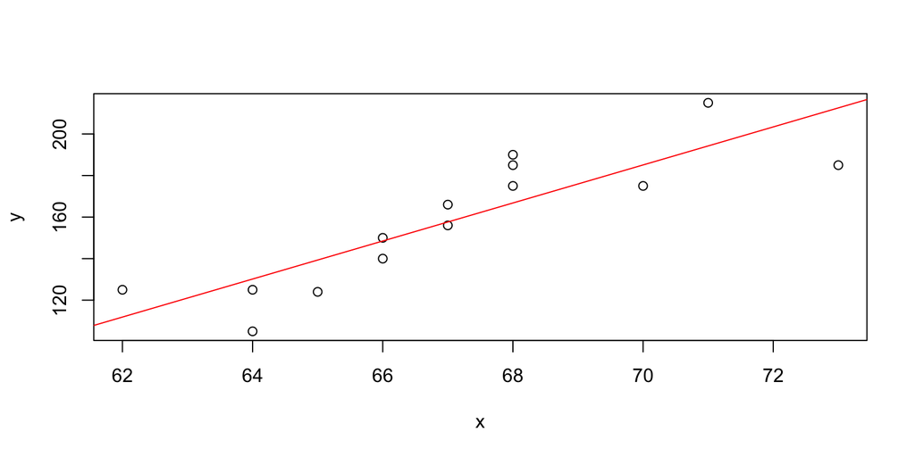

```
##         corr    intercept         coef
##    0.8562259 -455.6660342    9.1537002
```

```r
regline <- function(x, y){

  # lengths
  n_x = length(x)
  n_y = length(y)

  # means
  mean_x = mean(x)
  mean_y = mean(y)

  # sd_x, with no df correction
  sd_x = sqrt(sum((x - mean_x)^2) / (n_x))
  # sd_y, with no df correction
  sd_y = sqrt(sum((y - mean_y)^2) / (n_y))

  # cov(x, y)
  cov_x_y = mean((x - mean_x)*(y - mean_y))

  # cov(x, y) / (sd_x * sd_y)
  corr<-cov_x_y / (sd_x * sd_y)

  coef<-corr*(sd_y/sd_x)
  intercept<-mean(y)-coef*mean(x)

  res<-c(corr, intercept, coef)
  plot(x,y)
  abline(intercept, coef, col="red")
  names(res)<-c("corr","intercept","coef")
  return(c(res))
}

with(family, regline(fheight, fweight))
```

```r
regline <- function(y, x){
  # This function plots a scatterplot with the regression line in red.

  coefs <- regcoef(y, x)

  plot(x, y, pch=16)
  lines(x, (coefs[1]+coefs[2]*x), col="red", lwd=2)

}
```

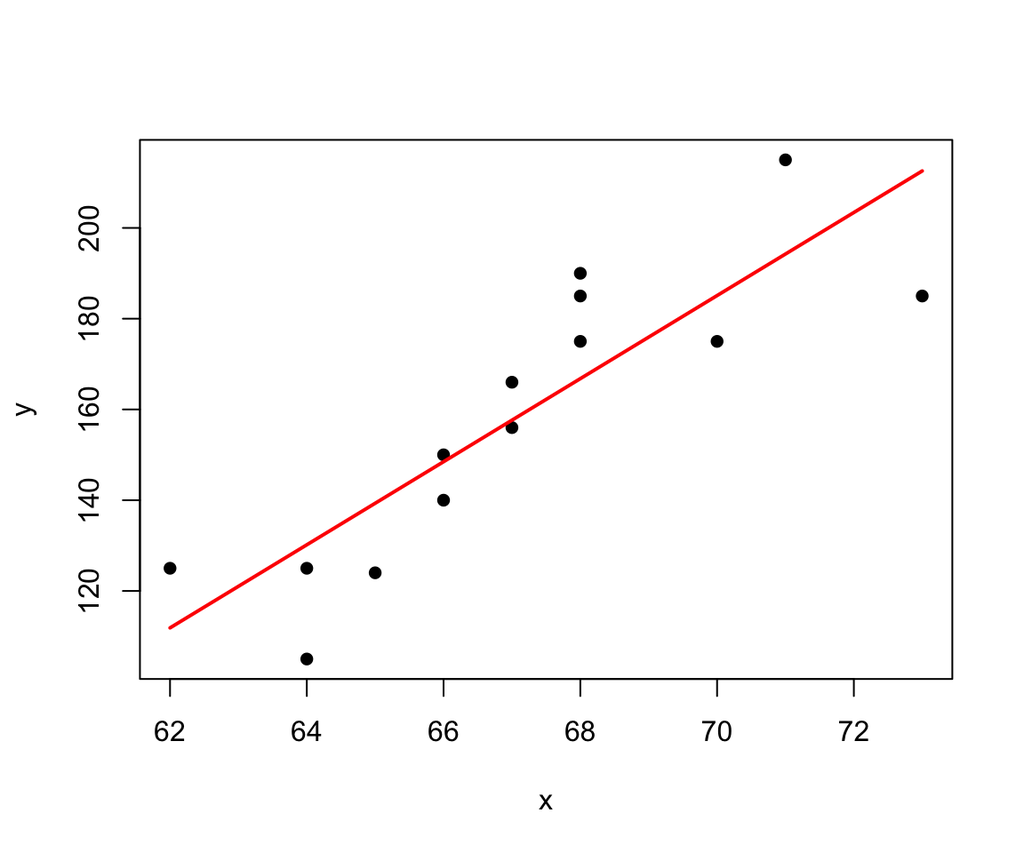

```r
regline(y=family$weight, x=family$height)
```

It is important that you understand the syntax line we use to add the regression line!

```r
  lines(x, (coefs[1]+coefs[2]*x), col="red", lwd=2)
```

What is the `y` argument here?

E. One last step! Let’s add the SD line to the plot as well. Modify `regline()` including one or more lines of code that add the SD line to the plot.

Hint: How do we calculate the slope of the SD line? What property of the SD line do we need to calculate the intercept?

```r
regline <- function(y, x){
  # This function plots a scatterplot with the regression line in red and
  # the SD line in blue.
  }
```

Again, the only output of the function should be the plot.

One way of doing this:

```r
regline <- function(y, x){
  # This function plots a scatterplot with the regression line in red and
  # the SD line in blue.

  coefs <- regcoef(y, x)

  plot(x, y, pch=16)
  lines(x, (coefs[1]+coefs[2]*x), col="red", lwd=2)

  # SD LINE
  # slope of the SD line
  sign <- cor(y,x)/abs(cor(y,x))
  b <- (sd(y)/sd(x))*sign
  # intercept of the SD line
  a <- mean(y)-b*mean(x)
  # adding the line to the plot
  lines(x, a+b*x, col="blue", lwd=2)

  # and just for completion let's add grey lines for the mean of x and y
  abline(v=mean(x), col="grey")
  abline(h=mean(y), col="grey")
  }
```

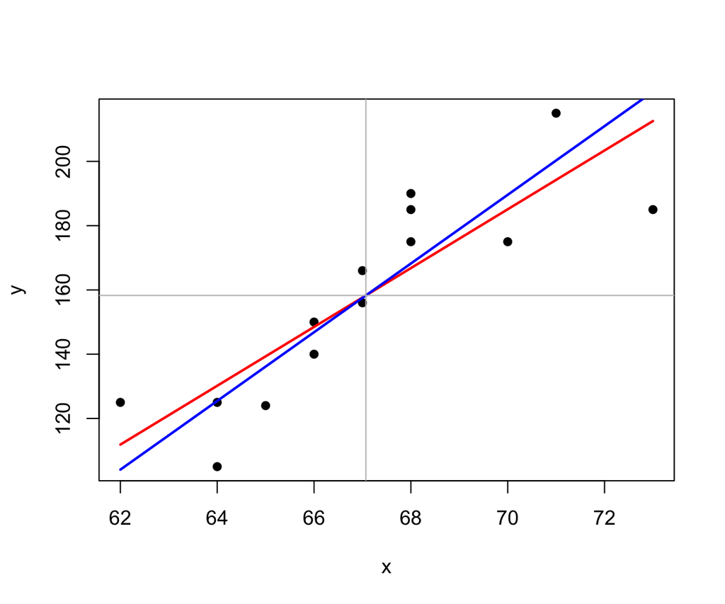

```r
regline(y=family$weight, x=family$height)
```

Why are the regression and SD lines quite similar here?

- Because the correlation between `x` and `y` here ir 0.8562259. With a weaker correlation, lines would diverge more.